# Single Factor, Random Effects Problem Set

# Introduction

This problem set is associated with the section “Single Factor, Random Effects ANOVA” on doe.dscoe.org. It also refers to the problem set from “Single Factor, Fixed Effects ANOVA” on the same site.

This problem set requires the following packages:

```r
library(tidyverse)
```

# Conceptual

In the Single Factor, Fixed Effects Problem Set , there were two simulations assessed with a single factor, fixed effects ANOVA:

- A tank simulation where the maximum range of the main gun could take the values of 1km, 2km, 3km, 4km, 5km.
- A soldier load experiment where soldiers’ load could be ‘unloaded’, ‘fighting’ or ‘full’ loads.

If, instead of prescribing the levels, the experimenter had randomly selected levels from a given range, i.e.:

- Choose a maximum range randomly in [1km, 5km].
- Choose a soldier load randomly in [0lb, 100lb].

how would the subsequent analysis have changed? Specifically address:

- Under these conditions, what is your hypothesis test?
- What can you conclude from these analyses?
- Why might an experimenter opt for the choice of random effects vs. fixed effects?

```
Under these conditions you would be testing to see if there was any variance in the factors Range and Load respectively.
The null hypothesis is H0: sd(tau) = 0; HA: sd(tau) != 0
You might choose to randomly select effects if you did not know that the factor would have an impact,
but could not test all levels of the factor.
```

# Communications Study

An analyst is working for the Future User Communications Cross Functional Team (CFT)[^1] and has been asked to see if a new soldier communications device (SCD) has any effect on the operational outcome of a corps fight. The CFT has proposed that the SCD has many properties, including:

- Weight that can vary between 0.5kg and 2kg.
- Range that can vary between 2km and 10km.
- Bandwidth that can vary between 1Mbps and 10 Mbps.
- Error rate that can vary between 0.1% and 1.0%.
- Usage time that can vary between 8 hours and 24 hours.

You know[^2] that with five factors at only two levels each, you would have to test $2^5 = 32$ different treatment combinations[^3] at a minimum to check all of the possible low and high combinations. You also know that you do not have time to do this yet; the CFT commander simply wants to know if the communications device has any bearing on the fight. You have sufficient time to run 15 simulations. You therefore randomly define five systems with random values chosen from each of the above ranges. You further identify two measures by which to express an effect - the kills achieved and the kills received. Given the data set commo.csv , answer the following questions:

```r
# This is how the data was generated; irrelevant to the problem, but useful for future reference
# weight <- runif(5, .5, 2)
# range <- runif(5, 2, 10)
# bandwidth <- runif(5, 1, 10)
# errorrate <- runif(5, .1, 1)
# time <- runif(5, 8, 24)
# system <- 1:5
# myDF <- data.frame(system, weight, range, bandwidth, errorrate, time)
# myDF <- rbind(myDF, myDF, myDF)
# myDF$kills.achieved = 50 + 2*sin(myDF$system) + rnorm(15, 0, 1)
# myDF$kills.received = 50 + rnorm(15, 0, 2)
# write.csv(myDF, '/cloud/project/html/_Chapter3_1_ProblemSets/commo.csv', row.names = F)
```

## Read the Data and Format as Required

```r
# Read the data
commo <- read.csv('./commo.csv')
# Make the system a factor
commo$system <- as.factor(commo$system)
# Note that in our example, we're choosing only five of the infinite number of combinations of system attributes randomly
# The exact attributes: range, etc.. do not matter; just the system "name"
```

## Visualize the Data

Show the data in some manner, to include the mean response. What do you observe about the data initially?

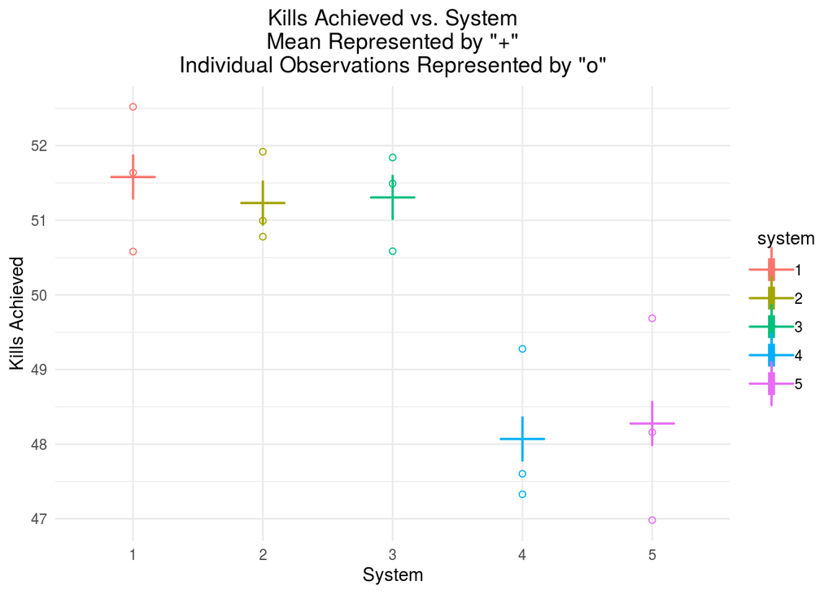

```r
# You can visualize the data as a box plot, but recall you only have 3 x replicates, so that may be somewhat confusing
# I opted to plot each point and add the means for each of the two responses

# Plot the Response Kills Achieved
ggplot(data = commo %>% group_by(system), aes(x = system, y = kills.achieved, color = system)) +
  stat_summary(fun = mean, shape = 3, size = 2) +
  geom_point(shape = 21) +
  xlab('System') + ylab('Kills Achieved') + ggtitle('Kills Achieved vs. System\nMean Represented by "+"\nIndividual Observations Represented by "o"') +
  theme_minimal() +
  theme(plot.title = element_text(hjust = .5))
```

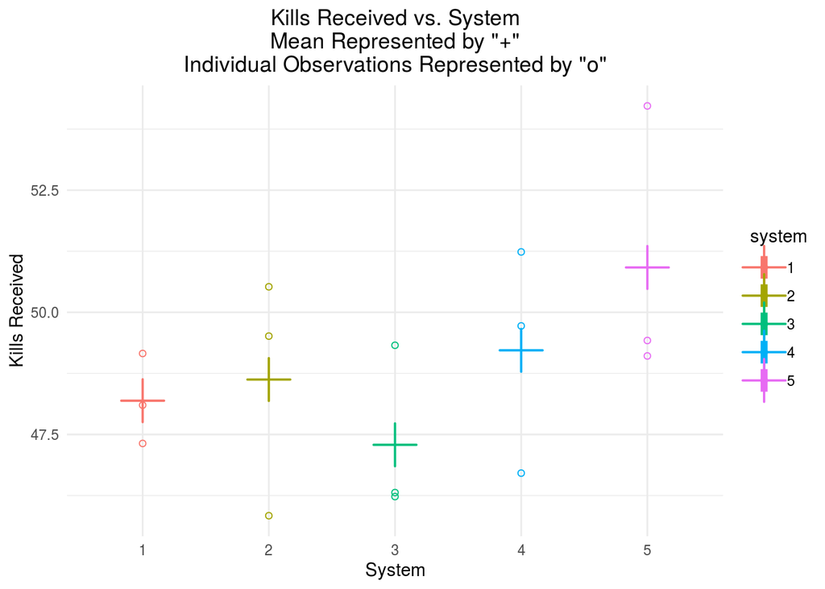

```
It appears that the system choice does have an effect on the kills achieved (note the distinction between 1, 2, 3 vs. 4, 5).
It is not completely clear if kills received has an effect.
```

```r
# Plot the Response Kills Received
ggplot(data = commo %>% group_by(system), aes(x = system, y = kills.received, color = system)) +
  stat_summary(fun = mean, shape = 3, size = 2) +
  geom_point(shape = 21) +
  xlab('System') + ylab('Kills Received') + ggtitle('Kills Received vs. System\nMean Represented by "+"\nIndividual Observations Represented by "o"') +
  theme_minimal() +
  theme(plot.title = element_text(hjust = .5))
```

## Conduct an ANOVA: Kills Achieved

For the response `kills.achieved` conduct an ANOVA to determine if the choice of communications system has an effect. Ensure to:

- Identify the type of ANOVA / hypothesis test.

```
This is a single factor, random effects model.  My null hypothesis is that the variance on the treatment
effect for the factor "communciations system" is 0; the alternative hypothesis is that it is non-zero.

Note that there is no hypothesis about the effect of range, bandwidth, etc...
I'll use alpha = .05
```

- Interpret your results

```r
# Conduct my ANOVA in the usual manner
aov.kills.achieved <- aov(kills.achieved ~ system, data = commo)
summary(aov.kills.achieved)
```

```
##             Df Sum Sq Mean Sq F value  Pr(>F)
## system       4  37.12   9.281   9.913 0.00165 **
## Residuals   10   9.36   0.936
## ---
## Signif. codes:  0 '***' 0.001 '**' 0.01 '*' 0.05 '.' 0.1 ' ' 1
```

```r
# I can safely reject my null hypothesis for my alpha, so I conclude
# that the variance on the treatment effect of commo system is non-zero
# meaning that the choice of commo system can, in at least some instances
# have an impact on this measure.
```

- Check your assumptions.

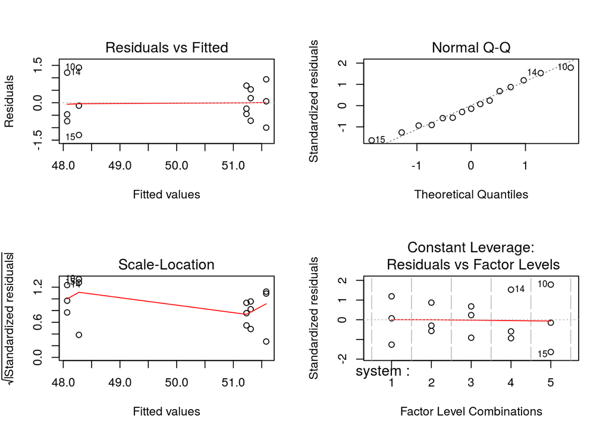

```r
# First I'll look at my assumptions graphically:
par(mfrow = c(2, 2))
plot(aov.kills.achieved)
```

```r
# Normality
# The QQ plot appears normal

# Homoskedasticity
# The variance appears constant across fitted values and residuals

# Independence
# No major patterns appear in any of the plots

# Second I'll check my assumptions numerically:

# Normality
shapiro.test(aov.kills.achieved$residuals)
```

```
##
##  Shapiro-Wilk normality test
##
## data:  aov.kills.achieved$residuals
## W = 0.96836, p-value = 0.8331
```

```r
# Given a p-value of ~.83, I fail to reject the null that the residuals are normally distributed

# Homoskedasticity
bartlett.test(aov.kills.achieved$residuals ~ commo$system)
```

```
##
##  Bartlett test of homogeneity of variances
##
## data:  aov.kills.achieved$residuals by commo$system
## Bartlett's K-squared = 1.4746, df = 4, p-value = 0.8311
```

```r
# Given a p-value of ~ .83, I fail to reject the null that the variance among the residuals is 0
# Note, the fact that the two p-values are .83 is purely coincidental!

# We don't have any collection order, so there is nothing to really check for regarding independence

# I can safely conclude I have met my assumptions
```

## Conduct an ANOVA: Kills Received

For the response `kills.received` conduct an ANOVA to determine if the choice of communications system has an effect. Ensure to:

- Identify the type of ANOVA / hypothesis test.

```
No change from the previous section
```

- Interpret your results

```r
# Conduct my ANOVA in the usual manner
aov.kills.received <- aov(kills.received ~ system, data = commo)
summary(aov.kills.received)
```

```
##             Df Sum Sq Mean Sq F value Pr(>F)
## system       4  22.02   5.505   1.167  0.382
## Residuals   10  47.17   4.717
```

```r
# Given a p-value of .382, I fail to reject my null, meaning
# I can conclude that the choice of commo system does not have an effect
# on kills received.
```

- Check your assumptions.

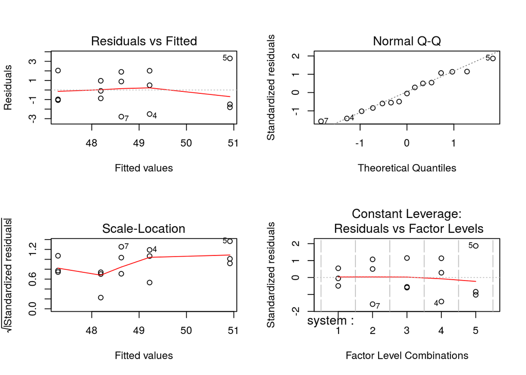

```r
# First I'll look at my assumptions graphically:
par(mfrow = c(2, 2))
plot(aov.kills.received)
```

```r
# Normality
# The QQ plot appears normal

# Homoskedasticity
# The variance appears constant across fitted values and residuals

# Independence
# No major patterns appear in any of the plots

# Second I'll check my assumptions numerically:

# Normality
shapiro.test(aov.kills.received$residuals)
```

```
##
##  Shapiro-Wilk normality test
##
## data:  aov.kills.received$residuals
## W = 0.96093, p-value = 0.7086
```

```r
# Given a p-value of ~.71, I fail to reject the null that the residuals are normally distributed

# Homoskedasticity
bartlett.test(aov.kills.received$residuals ~ commo$system)
```

```
##
##  Bartlett test of homogeneity of variances
##
## data:  aov.kills.received$residuals by commo$system
## Bartlett's K-squared = 1.9927, df = 4, p-value = 0.7371
```

```r
# Given a p-value of ~ .74, I fail to reject the null that the variance among the residuals is 0

# We don't have any collection order, so there is nothing to really check for regarding independence

# I can safely conclude I have met my assumptions
```

[^1]: Clearly this is made up.
[^2]: In this course, we’ll learn this when we discuss factorial experiments.
[^3]: We have not yet introduced this term. The point is, you do not have a chance to check all combinations.